# Projet_final_KDS

## Projet Final du Kit Data Science 2021

### Présenté par Nicolas ESDRAS - MS Big Data

##### Le projet final du Kit Data Science 2021 porte sur les données du Vendée Globe 2020-2021.

[figure not shown]

### Importation des librairies

```python
import pandas as pd
import numpy as np
from requests import get
import bs4
from bs4 import BeautifulSoup
import os
import datetime as dt
import xlwings
import seaborn as sns
import re
import matplotlib.pyplot as plt
import sklearn
from sklearn.linear_model import LinearRegression
```

### 1/ Acquisition et chargement des données

Dans cette partie, le but sera de créer un DataFrame comportant l'ensemble des fichiers csv de l'adresse suivante : https://www.vendeeglobe.org/fr/classement

#### Voici comment nous allons proceder pour les deux DataFrame (Classement et Glossaire) :

- Téléchargement des fichiers Excels (WebScrapping)
- Concaténation des fichiers si besoin
- Nettoyage des données

#### DataFrame Classement

```python
"""

url = "https://www.vendeeglobe.org/fr/classement"
options = soup.find_all("select")

print('********** DEBUT DU TELECHARGEMENT **********')

count_file = 0

for i in options[0]:
    if type(i) != bs4.element.Tag:
        continue
    file_name = i['value']
    url_path = 'https://www.vendeeglobe.org/download-race-data/vendeeglobe_{}.xlsx'.format(file_name)
    response = get(url_path)
    file = open('data/{}.xlsx'.format(file_name), 'wb')
    file.write(response.content)
    count_file += 1
    print(i['value'])

print(f'Il y a {count_file} fichiers excel telechargés.')
print('********** FIN DU TELECHARGEMENT **********')

"""
```

[output not shown]

```python
path = '/Users/nico/Documents/GitHub/Nicolas_ESDRAS_KDS/Projet/data2'

list = os.listdir(path)
number_files = len(list)
print(f'Il a {number_files} fichiers présents.')
```

```
Il a 703 fichiers présents.
```

```python
data_list = []
columns=['Date','Rang', 'Nat. / Voile','Skipper / Bateau', 'Heure FR', 'Latitude',
         'Longitude', 'Cap30', 'Vitesse30', 'VMG30', 'Distance30', 'CapLast', 'VitesseLast','VMGLast',
         'DistanceLast', 'Cap24', 'Vitesse24','VMG24', 'Distance24', "DTF", "DTL"]

for f in os.listdir(path):
    df = pd.read_excel(os.path.join(path, f),skiprows=4,names=columns,skipfooter=4)
    df['Date'] = f.replace(".xlsx","")
    data_list.append(df2)

df_class = pd.concat(data_list)

df_class[["Skipper","Bateau"]] = df_class["Skipper / Bateau"].str.rsplit(pat="\n",expand=True)
df_class = df_class.drop("Skipper / Bateau", axis=1)

df_class = df_class.rename(columns={'Cap30' : 'Cap30 (°)',
                                    'CapLast' : 'CapLast (°)',
                                    'Cap24' : 'Cap24 (°)',
                                    'Vitesse30' : 'Vitesse30 (kts)',
                                    'VitesseLast' : 'VitesseLast (kts)',
                                    'Vitesse24' : 'Vitesse24 (kts)',
                                    'VMG30' : 'VMG30 (kts)',
                                    'VMGLast' : 'VMGLast (kts)',
                                    'VMG24' : 'VMG24 (kts)',
                                    'Distance30' : 'Distance30 (nm)',
                                    'DistanceLast' : 'DistanceLast (nm)',
                                    'Distance24' : 'Distance24 (nm)',
                                    'DTF' : 'DTF (nm)',
                                    'DTL' : 'DTL (nm)',})


df_class = df_class[['Date', 'Rang', 'Nat. / Voile', 'Skipper',
                     'Bateau', 'Heure FR', 'Latitude', 'Longitude',
                     'Cap30 (°)', 'Vitesse30 (kts)', 'VMG30 (kts)','Distance30 (nm)',
                     'CapLast (°)', 'VitesseLast (kts)', 'VMGLast (kts)', 'DistanceLast (nm)',
                     'Cap24 (°)', 'Vitesse24 (kts)', 'VMG24 (kts)', 'Distance24 (nm)', 'DTF (nm)', 'DTL (nm)']]

df_class = df_class.replace({'\n': ' '}, regex=True)
df_class = df_class.replace({'kts': ' '}, regex=True)
df_class = df_class.replace({'°': ' '}, regex=True)
df_class = df_class.replace({'nm': ' '}, regex=True)

df_class['Nat'] = df_class['Nat. / Voile'].apply(lambda x: re.search('[a-zA-Z]{3} ', x).group(0)[:-1])
df_class['Voile'] = df_class['Nat. / Voile'].apply(lambda x: re.search('(\d+)', x).group(0))
df_class = df_class.drop(['Nat. / Voile'], axis=1)

df_class.dropna(how='any', inplace=True)

df_class.head()
```

|  | Date | Rang | Skipper | Bateau | Heure FR | Latitude | Longitude | Cap30 (°) | Vitesse30 (kts) | VMG30 (kts) | ... | VMGLast (kts) | DistanceLast (nm) | Cap24 (°) | Vitesse24 (kts) | VMG24 (kts) | Distance24 (nm) | DTF (nm) | DTL (nm) | Nat | Voile |
| --- | --- | --- | --- | --- | --- | --- | --- | --- | --- | --- | --- | --- | --- | --- | --- | --- | --- | --- | --- | --- | --- |
| 0 | 20201217_140000 | 1 | Yannick Bestaven | Maître Coq IV | 14:30 FR | 55 28.90'S | 152 57.15'E | 102 | 21.5 | 21.5 | ... | 19.0 | 56.9 | 98 | 18.1 | 17.7 | 435.5 | 11804.6 | 0.0 | FRA | 17 |
| 1 | 20201217_140000 | 2 | Thomas Ruyant | LinkedOut | 14:30 FR | 53 51.84'S | 150 48.37'E | 78 | 18.0 | 15.1 | ... | 16.2 | 53.7 | 92 | 15.2 | 14.0 | 364.2 | 11905.4 | 100.8 | FRA | 59 |
| 2 | 20201217_140000 | 3 | Charlie Dalin | APIVIA | 14:30 FR | 54 58.24'S | 149 24.05'E | 97 | 16.4 | 16.2 | ... | 17.0 | 51.1 | 101 | 19.1 | 18.6 | 459.4 | 11930.0 | 125.4 | FRA | 79 |
| 3 | 20201217_140000 | 4 | Jean Le Cam | Yes we Cam ! | 14:30 FR | 51 05.59'S | 141 19.16'E | 109 | 18.0 | 17.8 | ... | 17.7 | 54.5 | 100 | 17.8 | 16.3 | 427.0 | 12289.7 | 485.1 | FRA | 01 |
| 4 | 20201217_140000 | 5 | Boris Herrmann | Seaexplorer - Yacht Club De Monaco | 14:30 FR | 51 47.30'S | 140 13.99'E | 92 | 18.0 | 16.3 | ... | 17.6 | 55.2 | 105 | 17.8 | 17.0 | 427.7 | 12305.9 | 501.2 | MON | 10 |

5 rows × 23 columns

Regardons si des valeurs 'NaN' sont présentes dans le DataFrame

```python
df_class.isna().sum()
```

```
Date                 0
Rang                 0
Skipper              0
Bateau               0
Heure FR             0
Latitude             0
Longitude            0
Cap30 (°)            0
Vitesse30 (kts)      0
VMG30 (kts)          0
Distance30 (nm)      0
CapLast (°)          0
VitesseLast (kts)    0
VMGLast (kts)        0
DistanceLast (nm)    0
Cap24 (°)            0
Vitesse24 (kts)      0
VMG24 (kts)          0
Distance24 (nm)      0
DTF (nm)             0
DTL (nm)             0
Nat                  0
Voile                0
dtype: int64
```

#### DataFrame Voiliers

```python
url_glossaire = 'https://www.vendeeglobe.org/fr/glossaire'
requests.get(url_glossaire)
soup_glossaire = BeautifulSoup(requests.get(url_glossaire).content)

skipper_items = soup_glossaire.find_all('div', {'class':"sv-u-1 sv-u-s-1-2 sv-u-m-1-3 sv-u-l-1-6"})

# Utilisation d'un dictionnaire avant d'écrire le Dataframe.
boats_dict = {}

for soup_boat in skipper_items:
    boats_dict[soup_boat.find('h3', {'class':"boats-list__boat-name"}).text] = {
        'Skipper': soup_boat.find('span', {'class':"boats-list__skipper-name"}).text
    }

    for soup_li in soup_boat.find_all('li'):
        boats_dict[soup_boat.find('h3', {'class':"boats-list__boat-name"}).text][soup_li.text.split(':')[0]] = soup_li.text.split(':')[1]

df_boats = pd.DataFrame(boats_dict)
df_boats = df_boats.T
df_boats.dropna()
df_boats
```

|  | Skipper | Numéro de voile | Anciens noms du bateau | Architecte | Chantier | Date de lancement | Longueur | Largeur | Tirant d'eau | Déplacement (poids) | Nombre de dérives | Hauteur mât | Voile quille | Surface de voiles au près | Surface de voiles au portant |
| --- | --- | --- | --- | --- | --- | --- | --- | --- | --- | --- | --- | --- | --- | --- | --- |
| NEWREST - ART & FENÊTRES | Fabrice AMEDEO | FRA 56 | No Way Back, Vento di Sardegna | VPLP/Verdier | Persico Marine | 01 Août 2015 | 18,28 m | 5,85 m | 4,50 m | 7 t | foils | 29 m | monotype | 320 m2 | 570 m2 |
| PURE - Best Western® | Romain ATTANASIO | FRA 49 | Gitana Eighty, Synerciel, Newrest-Matmut | Bruce Farr Design | Southern Ocean Marine (Nouvelle Zélande) | 08 Mars 2007 | 18,28m | 5,80m | 4,50m | 9t | 2 | 28m | acier forgé | 280 m2 | 560 m2 |
| TSE - 4MYPLANET | Alexia BARRIER | FRA72 | Famille Mary-Etamine du Lys, Initiatives Coeu... | Marc Lombard | MAG France | 01 Mars 1998 | 18,28m | 5,54m | 4,50m | 9t | 2 | 29 m | acier | 260 m2 | 580 m2 |
| Maître CoQ IV | Yannick BESTAVEN | 17 | Safran 2 - Des Voiles et Vous | Verdier - VPLP | CDK Technologies | 12 Mars 2015 | 18,28 m | 5,80 m | 4,50 m | 8 t | foils | 29 m | acier mécano soudé | 310 m2 | 550 m2 |
| CHARAL | Jérémie BEYOU | 08 | NaN | VPLP | CDK Technologies | 18 Août 2018 | 18,28 m | 5,85 m | 4,50 m | 8t | foils | 29 m | acier | 320 m2 | 600 m2 |
| LA MIE CÂLINE - ARTISANS ARTIPÔLE | Arnaud BOISSIÈRES | FRA 14 | Ecover3, Président, Gamesa, Kilcullen Voyager... | Owen Clarke Design LLP - Clay Oliver | Hakes Marine - Mer Agitée | 03 Août 2007 | 18,28 m | 5,65 m | 4,50 m | 7,9 tonnes | foils | 29 m | basculante avec vérin | 300 m² | 610 m² |
| BUREAU VALLEE 2 | Louis BURTON | 18 | Banque Populaire VIII | Verdier - VPLP | CDK Technologies | 09 Juin 2015 | 18,28 m | 5,80 m | 4,50 m | 7,6 t | foils | 28 m | acier | 300 m2 | 600 m2 |
| ONE PLANET ONE OCEAN | Didac COSTA | ESP 33 | Kingfisher - Educacion sin Fronteras - Forum ... | Owen Clarke Design | Martens Yachts | 02 Février 2000 | 18,28 m | 5,30 m | 4,50 m | 8,9 t | 2 | 26 m | acier | 240 m2 | 470 m2 |
| GROUPE SÉTIN | Manuel COUSIN | FRA 71 | Paprec-Virbac2, Estrella Damm, We are Water, ... | Bruce Farr Yacht Design | Southern Ocean Marine (Nouvelle-Zélande) | 02 Février 2007 | 18,28 m | 5,80 m | 4,50 m | 9 t | 2 asymétriques | 28,50 | basculante sur vérin hydraulique | 270 m2 | 560 m2 |
| BANQUE POPULAIRE X | Clarisse CREMER | FRA30 | Macif - SMA | Verdier - VPLP | CDK - Mer Agitée | 01 Mars 2011 | 18,28 m | 5,70 m | 4,5 m | 7,7 t | 2 | 29 m | acier forgé | 340 m2 | 570 m2 |
| APIVIA | Charlie DALIN | FRA 79 | NaN | Verdier | CDK technologies - MerConcept | 05 Août 2019 | 18,28 m | 5,85 m | 4,50 m | 8 t | foils | 29 m | acier | 350 m2 | 560 m2 |
| INITIATIVES-COEUR | Sam DAVIES | FRA109 | Maître CoQ - Banque Populaire VII- Foncia II | VPLP - Verdier | CDK Technologies | 20 Septembre 2010 | 18,28 m | 5,70 m | 4,50 m | 7,8 t | foils | 27 m | acier forgé | 300 m2 | 600 m2 |
| MERCI | Sébastien DESTREMAU | 69 | Foresight Natural Energy, Maisonneuve | Lavanos | Artech do Brasil | 15 Janvier 2005 | 18,28 m | 5,60 m | 4,50 m | 8,5 t | 2 | 29 m | acier | 250 m2 | 650 m2 |
| OMIA - WATER FAMILY | Benjamin DUTREUX | FRA09 | Spirit of Yukoh, Neutrogena, Hugo Boss, Estre... | Bruce Farr Design | Offshore Challenge - Cowes | 03 Juillet 2007 | 18,28 m | 5,85 m | 4,50 m | 8 t | 2 | 29 m | acier forgé | 300 m2 | 700 m2 |
| PRB | Kevin ESCOFFIER | FRA 85 | NaN | Verdier - VPLP | CDK Technologies | 08 Mars 2010 | 18,28 m | 5,50 m | 4,50 m | NC | foils | 27,40 m | Acier mécano soudé | 300 m2 | 600 m2 |
| Compagnie du Lit / Jiliti | Clément GIRAUD | FRA83 | Delta Dore, Bureau Vallée, Vers un Monde sans... | Bruce Farr design | JMV Cherbourg | 26 Juillet 2006 | 18,28 m | 5,75 m | 4,50 m | 8,5 t | 2 | 29 m | acier forgé | 300 m2 | 620 m2 |
| MEDALLIA | Pip HARE | GBR77 | Armor Lux, We Are Water, La Fabrique | Pierre Rolland | Bernard Stamm | 03 Juillet 1999 | 18,28 m | 5,70 m | 4,50 m | 9 t | 2 | 29 m | carbone | 300 m2 | 580 m2 |
| SEAEXPLORER - YACHT CLUB DE MONACO | Boris HERRMANN | 16 | Edmond de Rothschild, Malizia - Yacht Club de... | Verdier - VPLP | Multiplast | 07 Août 2015 | 18,28 m | 5,70 m | 4,50 m | 7,6 t | foils | 29 m | acier | 290 m2 | 490 m2 |
| STARK | Ari HUUSELA | FIN222 | Aviva, GAES Centros Auditivos | Owen Clarke Design | Hakes Marine - Wellington (Nouvelle-Zélande) | 06 Août 2007 | 18,28 m | 5,80 m | 4,50 m | 8,5 t | 2 | 28 m | acier | 270 m2 | 580 m2 |
| MACSF | Isabelle JOSCHKE | FRA 27 | Quéguiner, Safran | Verdier - VPLP | Chantier Naval de Larros | 04 Juillet 2007 | 18,28 m | 5,60 m | 4,50 m | 7,7 t | foils | 27 m | acier | 300 m2 | 650 m2 |
| Yes We Cam! | Jean LE CAM | 001 | Cheminées Poujoulat, Mare, Maître CoQ, Mapfre... | Bruce Farr design | CDK Technologies | 03 Janvier 2007 | 18,28 m | 5,90 m | 4,50 m | 8 t | 2 | 28 m | acier forgé | 300 m2 | 620 m2 |
| TIME FOR OCEANS | Stéphane LE DIRAISON | FRA 92 | Hugo Boss, Energa, Compagnie du Lit-Boulogne ... | Finot-Conq Design | Neville Hutton | 01 Juin 2007 | 18,28 m | 5,84 m | 4,50 m | 8,5 t | foils | 28 m | monotype | 300 m2 | 550 m2 |
| CAMPAGNE DE FRANCE | Miranda MERRON | FRA50 | Great America IV, Mirabaud, Temenos | Owen Clarke | Southern Ocean Marine, Tauranga | 04 Mai 2006 | 18,28 m | 5,50 m | 4,50 m | 8,5 t | 2 | 28 m | carbone | 330 m2 | 600 m2 |
| PRYSMIAN GROUP | Giancarlo PEDOTE | ITA 34 | Saint-Michel - Virbac | VPLP - Verdier | Multiplast | 02 Avril 2015 | 18,28 m | 5,80 m | 4,5 m | 8 t | foils | 29 m | acier forgé | 300 m2 | 600 m2 |
| LA FABRIQUE | Alan ROURA | SUI07 | Brit Air, Votre Nom autour du Monde, MACSF | Groupe Finot-Conq | Multiplast | 01 Août 2007 | 18,28 m | 5,90 m | 4,50 m | nc | foils | 27 m | carbone | 290 m2 | 580 m2 |
| LinkedOut | Thomas RUYANT | NaN | NaN | Verdier | Persico | 03 Septembre 2019 | 18,28 m | 5,85 m | 4,50 m | 8 t | foils | 29 m | acier forgé | 350 m2 | 560 m2 |
| GROUPE APICIL | Damien SEGUIN | FRA1000 | Comme Un Seul Homme, DCNS | Groupe Finot-Conq | Multiplast | 10 Août 2008 | 18,28 m | 5,85 m | 4,50 m | 8,5 t | 2 | 29 m | acier forgé | 350 m2 | 610 m2 |
| DMG MORI Global One | Kojiro SHIRAISHI | JPN 11 | NaN | VPLP | Multiplast | 05 Septembre 2019 | 18,28 m | 5,85 m | 4,50 m | 8 t | foils | 29 m | acier forgé | 320 m2 | 580 m2 |
| ARKEA PAPREC | Sébastien SIMON | 4 | NaN | Juan Kouyoumdjian | CDK Technologies / Assemblage | 19 Juillet 2019 | 18,28 m | 5,70 m | 4,50 m | 8 t | foiler | 29 m | Inox usiné | 260 m2 | 600 m2 |
| V and B-MAYENNE | Maxime SOREL | FRA53 | Le Souffle du Nord, Groupe Bel | Verdier - VPLP | Indiana Yachting (Scarlino, Italie) | 07 Septembre 2007 | 18,28 m | 5,50 m | 4,50 m | 7,7 t | 2 | 29 m | acier | 365 m2 | 700 m2 |
| HUGO BOSS | Alex THOMSON | GBR 99 | NaN | VPLP - Alex Thomson Racing (led by Pete Hobson) | Carrington Boats | 15 Août 2019 | 18,28 m | 5,40 m | 4,50 m | 7,7 t | foils | 29 m | acier forgé | 330 m2 | 630 m2 |
| L'OCCITANE EN PROVENCE | Armel TRIPON | 2 | NaN | Samuel Manuard | Black Pepper© | 31 Janvier 2020 | 18,28 m | 5,50 m | 4,50 m | 7,8 t | foils | 28 m | acier forgé | 270 m2 | 535 m2 |
| CORUM L'EPARGNE | Nicolas TROUSSEL | FRA 6 | NaN | Juan Kouyoumdjian | CDK technologies - Mer Agitée | 15 Mai 2020 | 18,28 m | 5,70 m | 4,50 m | 7,9 t | foils | 27,30 m | NaN | 270 m2 | 535 m2 |

```python
df_class.dtypes
```

```
Date                 object
Rang                 object
Skipper              object
Bateau               object
Heure FR             object
Latitude             object
Longitude            object
Cap30 (°)            object
Vitesse30 (kts)      object
VMG30 (kts)          object
Distance30 (nm)      object
CapLast (°)          object
VitesseLast (kts)    object
VMGLast (kts)        object
DistanceLast (nm)    object
Cap24 (°)            object
Vitesse24 (kts)      object
VMG24 (kts)          object
Distance24 (nm)      object
DTF (nm)             object
DTL (nm)             object
Nat                  object
Voile                object
dtype: object
```

```python
num_col = ['Cap30 (°)', 'Vitesse30 (kts)', 'VMG30 (kts)','Distance30 (nm)',
           'CapLast (°)', 'VitesseLast (kts)', 'VMGLast (kts)', 'DistanceLast (nm)',
           'Cap24 (°)', 'Vitesse24 (kts)', 'VMG24 (kts)', 'Distance24 (nm)', 'DTF (nm)', 'DTL (nm)']
df_class[num_col] = df_class[num_col].astype(float)
df_class['Rang'] = df_class['Rang'].astype(float)
```

```python
df_all = df_class.merge(df_boats, on='Skipper', how='left' )
df_all
```

|  | Date | Rang | Skipper | Bateau | Heure FR | Latitude | Longitude | Cap30 (°) | Vitesse30 (kts) | VMG30 (kts) | ... | Date de lancement | Longueur | Largeur | Tirant d'eau | Déplacement (poids) | Nombre de dérives | Hauteur mât | Voile quille | Surface de voiles au près | Surface de voiles au portant |
| --- | --- | --- | --- | --- | --- | --- | --- | --- | --- | --- | --- | --- | --- | --- | --- | --- | --- | --- | --- | --- | --- |
| 0 | 20201217_140000 | 1.0 | Yannick Bestaven | Maître Coq IV | 14:30 FR | 55 28.90'S | 152 57.15'E | 102.0 | 21.5 | 21.5 | ... | NaN | NaN | NaN | NaN | NaN | NaN | NaN | NaN | NaN | NaN |
| 1 | 20201217_140000 | 2.0 | Thomas Ruyant | LinkedOut | 14:30 FR | 53 51.84'S | 150 48.37'E | 78.0 | 18.0 | 15.1 | ... | NaN | NaN | NaN | NaN | NaN | NaN | NaN | NaN | NaN | NaN |
| 2 | 20201217_140000 | 3.0 | Charlie Dalin | APIVIA | 14:30 FR | 54 58.24'S | 149 24.05'E | 97.0 | 16.4 | 16.2 | ... | NaN | NaN | NaN | NaN | NaN | NaN | NaN | NaN | NaN | NaN |
| 3 | 20201217_140000 | 4.0 | Jean Le Cam | Yes we Cam ! | 14:30 FR | 51 05.59'S | 141 19.16'E | 109.0 | 18.0 | 17.8 | ... | NaN | NaN | NaN | NaN | NaN | NaN | NaN | NaN | NaN | NaN |
| 4 | 20201217_140000 | 5.0 | Boris Herrmann | Seaexplorer - Yacht Club De Monaco | 14:30 FR | 51 47.30'S | 140 13.99'E | 92.0 | 18.0 | 16.3 | ... | NaN | NaN | NaN | NaN | NaN | NaN | NaN | NaN | NaN | NaN |
| ... | ... | ... | ... | ... | ... | ... | ... | ... | ... | ... | ... | ... | ... | ... | ... | ... | ... | ... | ... | ... | ... |
| 18976 | 20201217_140000 | 23.0 | Miranda Merron | Campagne de France | 14:30 FR | 40 45.15'S | 55 39.86'E | 125.0 | 10.3 | 10.1 | ... | NaN | NaN | NaN | NaN | NaN | NaN | NaN | NaN | NaN | NaN |
| 18977 | 20201217_140000 | 24.0 | Clément Giraud | Compagnie du lit - Jiliti | 14:30 FR | 42 13.23'S | 53 49.76'E | 100.0 | 13.5 | 13.1 | ... | NaN | NaN | NaN | NaN | NaN | NaN | NaN | NaN | NaN | NaN |
| 18978 | 20201217_140000 | 25.0 | Alexia Barrier | TSE - 4myplanet | 14:30 FR | 41 22.96'S | 54 12.69'E | 106.0 | 12.1 | 12.0 | ... | NaN | NaN | NaN | NaN | NaN | NaN | NaN | NaN | NaN | NaN |
| 18979 | 20201217_140000 | 26.0 | Ari Huusela | Stark | 14:30 FR | 42 16.45'S | 48 42.92'E | 99.0 | 12.9 | 12.5 | ... | NaN | NaN | NaN | NaN | NaN | NaN | NaN | NaN | NaN | NaN |
| 18980 | 20201217_140000 | 27.0 | Sébastien Destremau | Merci | 14:30 FR | 42 08.83'S | 46 23.33'E | 76.0 | 4.6 | 4.2 | ... | NaN | NaN | NaN | NaN | NaN | NaN | NaN | NaN | NaN | NaN |

18981 rows × 37 columns

### 2/ Exploration des données

Regardons la distance parcourue en moyenne en 24h par équipe.

```python
df_class.groupby(['Nat','Voile','Bateau'])['Distance24 (nm)'].mean().sort_values(ascending=False)
```

```
Nat  Voile  Bateau
FRA  79     APIVIA                                    459.4
ITA  34     Prysmian Group                            438.2
FRA  17     Maître Coq IV                             435.5
     18     Bureau Vallée 2                           432.7
     8      Charal                                    429.4
MON  10     Seaexplorer - Yacht Club De Monaco        427.7
FRA  01     Yes we Cam !                              427.0
     27     MACSF                                     423.9
     1000   Groupe APICIL                             419.5
     09     OMIA - Water Family                       393.6
     71     Groupe Sétin                              384.5
     92     Time For Oceans                           384.1
     53     V And B Mayenne                           383.9
GBR  777    Medallia                                  371.8
ESP  33     One Planet One Ocean                      370.5
FRA  59     LinkedOut                                 364.2
JPN  11     DMG MORI Global One                       363.7
FRA  30     Banque Populaire X                        357.2
     49     Pure - Best Western Hotels and Resorts    348.2
FIN  222    Stark                                     307.6
FRA  14     La Mie Câline - Artisans Artipôle         292.2
     02     L'Occitane en Provence                    286.6
SUI  7      La Fabrique                               280.4
FRA  83     Compagnie du lit - Jiliti                 243.3
     50     Campagne de France                        237.7
     72     TSE - 4myplanet                           236.2
     69     Merci                                      55.7
Name: Distance24 (nm), dtype: float64
```

Regardons le classement moyen de chaque équipe.

```python
df_class.groupby(['Nat','Voile','Bateau'])['Rang'].mean().sort_values()
```

```
Nat  Voile  Bateau
FRA  17     Maître Coq IV                              1.0
     59     LinkedOut                                  2.0
     79     APIVIA                                     3.0
     01     Yes we Cam !                               4.0
MON  10     Seaexplorer - Yacht Club De Monaco         5.0
FRA  1000   Groupe APICIL                              6.0
     09     OMIA - Water Family                        7.0
     18     Bureau Vallée 2                            8.0
     27     MACSF                                      9.0
ITA  34     Prysmian Group                            10.0
FRA  53     V And B Mayenne                           11.0
     30     Banque Populaire X                        12.0
     49     Pure - Best Western Hotels and Resorts    13.0
     02     L'Occitane en Provence                    14.0
SUI  7      La Fabrique                               15.0
FRA  14     La Mie Câline - Artisans Artipôle         16.0
     92     Time For Oceans                           17.0
GBR  777    Medallia                                  18.0
ESP  33     One Planet One Ocean                      19.0
FRA  71     Groupe Sétin                              20.0
     8      Charal                                    21.0
JPN  11     DMG MORI Global One                       22.0
FRA  50     Campagne de France                        23.0
     83     Compagnie du lit - Jiliti                 24.0
     72     TSE - 4myplanet                           25.0
FIN  222    Stark                                     26.0
FRA  69     Merci                                     27.0
Name: Rang, dtype: float64
```

Ce graphique nous montre la répartition des différentes nationalités.

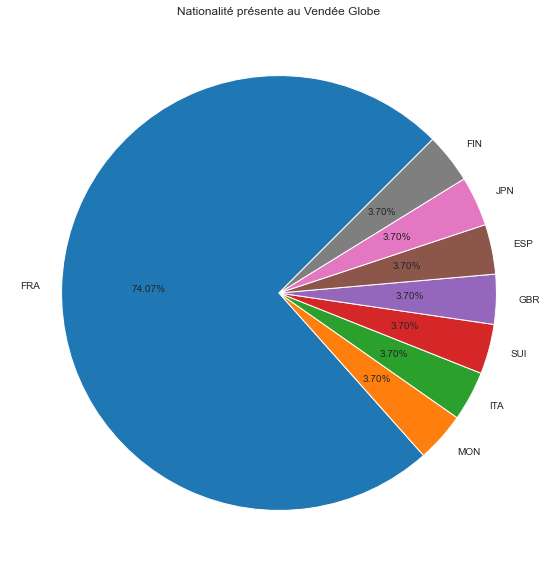

```python
fig, ax = plt.subplots(figsize=(20,10))
ax.pie(df_class['Nat'].value_counts(), labels=df_class['Nat'].unique(), autopct='%2.2f%%', startangle=45)
plt.title("Nationalité présente au Vendée Globe")
plt.show()
fig.savefig('Nationalité présente au Vendée Globe.png')
```

La France étant sur-représenté, il est normal de retrouver les différentes équipes dans le haut du classement

### 3/ Analyse

De manière Visuel nous essayerons d'observer s'il y a une corrélation entre le rang et différentes variables

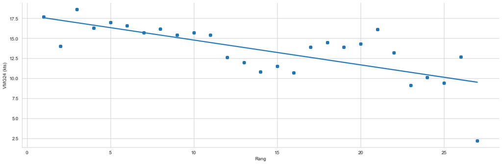

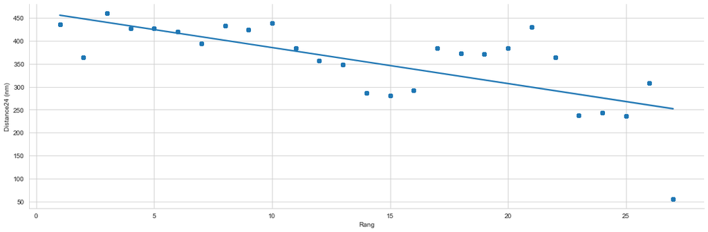

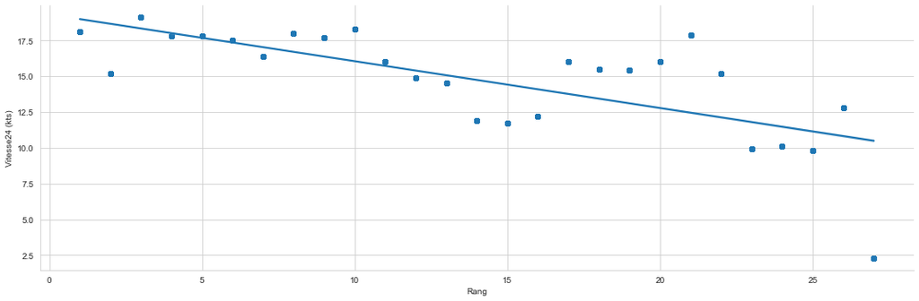

```python
a = sns.lmplot(x='Rang', y='VMG24 (kts)',
           data=df_class,
           height=5, aspect=3)

b = sns.lmplot(x='Rang', y='Distance24 (nm)',
           data=df_class,
           height=5, aspect=3)

c = sns.lmplot(x='Rang', y='Vitesse24 (kts)',
               data=df_class,
               height=5, aspect=3)
plt.show()
```

[figure not shown]

```python
sns.regplot(x='Rang', y='VMG24 (kts)', data=df_class)
plt.show()
```

```python
VMG_rang_24h = pd.DataFrame(df_class.groupby('Rang')['VMG24 (kts)'].mean())
Rang = VMG_rang_24h.index.values.reshape(-1,1)
VMG_24h = VMG_rang_24h['VMG24 (kts)']

reg = LinearRegression(fit_intercept=True)
reg.fit(Rang, VMG_24h)
VMG_pred = reg.predict(Rang)

coef = np.round(reg.coef_[0],4)
intercept = np.round(reg.intercept_,4)
r2 = np.round(sklearn.metrics.r2_score(VMG_24h, VMG_pred),4)

print(f'Correlation entre le rang et la vitesse VMG depuis 24 heures:\n\n\
- Coefficient : {coef}\n\
- Intercept : {intercept}\n\
- Score R2 : {r2}\n')
```

```
Correlation entre le rang et la vitesse VMG depuis 24 heures:

- Coefficient : -0.3103
- Intercept : 17.8852
- Score R2 : 0.5175
```